# Pitcher card

# Steven Cruz

RHP · KC

2026 · 56 G (2 GS) · 930 pitches · Apr 01 – Sep 23, 2026

Independent portfolio sample by Devin Jenkinson, not affiliated with any club. Every number is computed from public Statcast data.

Three big takeaways

1Attack

The 4-seam fastball is the put-away pitch. Use it to finish at-bats.

52% of two-strike pitches · 25% whiffs/swing (92 swings)

It grades 112 Stuff+. Next best two-strike miss rate: the slider at 21%.

2Avoid

Limit the slider. It is his most damaging pitch.

xRV/100 -0.55 shrunk (raw -1.89) · .488 xwOBAcon · 138 pitches

When behind in the count he throws it 3% of the time; the cutter grades +0.87 there instead.

3Watch

Use the 4-seam fastball up in the zone. It beats the league rate there.

38% whiffs/swing up (148 sw) vs 28% MLB FF up

50% of his 4-seam fastballs finish in the top third. Too few swings down (33) to compare.

Charts

### Movement

The SL finishes 20 in from his FF, with 16 in more glove-side run.

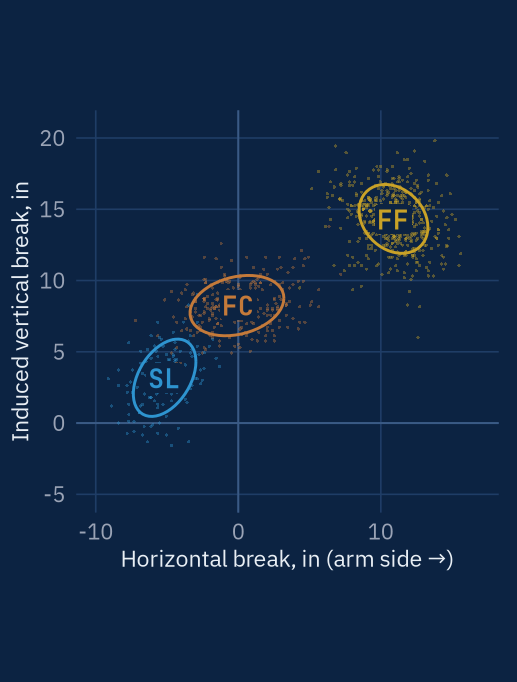

n = 927 pitches. Ellipses hold about 68% of each type; codes sit at the averages.

### Location by count

He throws 52% of pitches in the zone when behind and 56% when ahead.

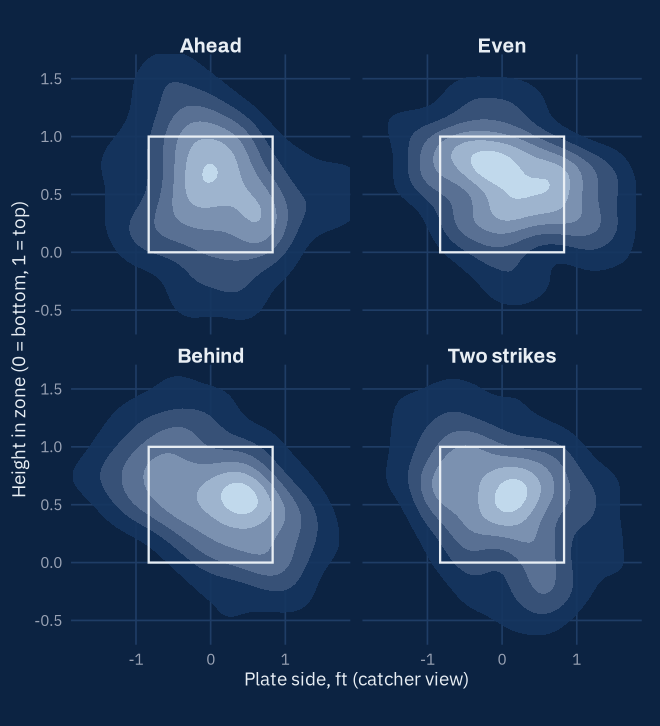

n = 927. Ahead 123 · even 323 · behind 192 · two strikes 289 pitches. Box = rule-book zone.

### Put-away

The FF is 52% of two-strike pitches vs 56% overall.

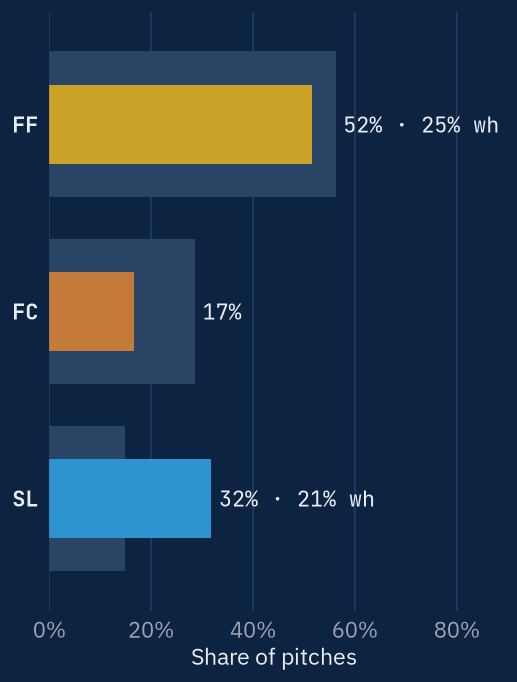

Two-strike n: FF 149, SL 92, FC 48. Grey bars = overall usage; wh = whiffs per swing (shown with 50+ swings).

### Arsenal

| Pitch | # | Use | Velo | IVB | HB | VAA | Whiff | Chase | xwOBAcon | xRV/100 | Stuff+ |
| --- | --- | --- | --- | --- | --- | --- | --- | --- | --- | --- | --- |
| 4-Seam (FF) | 523 | 56% | 98.5 | 14.3 | +10.9 | -4.4 | 29% | 29% | .421 | +0.04 | 112 |
| Cutter (FC) | 266 | 29% | 93.9 | 8.3 | +-0.0 | -5.6 | 29% | 26% | .291 | +0.87 | 98 |
| Slider (SL) | 138 | 15% | 89.4 | 3.1 | -5.2 | -6.8 | 24% | 29% | .488 | -0.55 | 92 |

IVB / HB in inches (HB + = arm side). VAA in degrees at the front of the plate. xRV/100 = expected run value per 100 pitches, pitcher’s view, shrunk with a 250-pitch prior. Stuff+ = this project’s shape-only model (100 = MLB average, 10 = 1 SD).

### Vs. batter hand

| Pitch | LHH # | Use | Whiff | xwOBAcon | RHH # | Use | Whiff | xwOBAcon |
| --- | --- | --- | --- | --- | --- | --- | --- | --- |
| FF | 304 | 55% | 35% | .347 | 219 | 59% | 20% | .317 |
| FC | 186 | 33% | 33% | .224 | 80 | 22% | – | .358 |
| SL | 66 | 12% | – | .414 | 72 | 19% | – | .201 |

Use = share of pitches to that side. Whiff = whiffs per swing, shown with 50+ swings.